# Marketing Analytics

Chapter 6 · Mechanisms & Heterogeneity

Nils Wlömert

Vienna University of Economics and Business (WU)

November 2026

## Before we start

**Paper quiz on Chapter 5, Part II** *(§5.7–5.10, 8 min)*

- Individual, closed book, counts toward participation

**Assignment 3** is running: deadline Group A Sun, Nov 22 · Group B Wed, Nov 25; debrief at the start of next session.

**Devices only when we code**

- **Input blocks:** laptops closed, phones away
- **Coding block** (40 min, at the end): laptops open, alone or with your neighbor; results via Menti, then two tables present

Today: interactions and marginal effects → three kinds of moderators → a 2 × 3 experiment → mediation → your group project → **one coding block with two cases** at the end.

## Today’s session

6.1 The average effect hides the interesting part  
6.2 Interactions and **marginal effects**  
6.3 Continuous × categorical  
6.4 Continuous × continuous  
6.5 Categorical × categorical: a **2 × 3 experiment**  
6.7 **Mediation**: why does it work?  
6.8 Your group project: **one moderator, one mediator**  
**Coding block**: two cases (40 min)

*Reading:* 6.6 The pitfalls of looking for heterogeneity

**Driving question:** *Why — and for whom — does it work?*

One new ingredient: the **product of two variables**.

# 6.1 The average effect hides the interesting part

## Smart Mix, second wave

- **1,200 users**, randomized to Smart Mix or control
- This time with **covariates**: plan (free/Premium), prior listening, tenure, device
- And one more variable: **new artists discovered** during the four weeks
- Average effect: **+3.7 hours** (95% CI 3.1–4.3)

The product team asks two more questions:

1. **For whom** does it work — free or Premium users? light or heavy listeners?
2. **Why** does it work — does it make users discover new music?

**Moderation** (for whom): the effect *depends on* a third variable. **Mediation** (why): the effect *runs through* a third variable. Easy to confuse — a moderator changes *how large*, a mediator is *part of the path*.

# 6.2 Interactions and marginal effects

## What an interaction term does

$$y = \beta_0 + \beta_1 x + \beta_2 z + \beta_3 (x \times z) + \varepsilon
\qquad \Rightarrow \qquad
\frac{\partial y}{\partial x} = \beta_1 + \beta_3 z$$

- The **marginal effect** of $x$ depends on $z$
- $\beta_1$ = effect of $x$ **when $z = 0$** (a *conditional* effect, not a “main effect”)
- $\beta_3$ = how much the effect of $x$ changes per unit of $z$
- Symmetric: effect of $z$ = $\beta_2 + \beta_3 x$

**Two rules:** (1) if zero is not a meaningful value of $z$, $\beta_1$ is not meaningful either → center (§6.4). (2) **Always keep both main terms**: in R, `x * z` = `x + z + x:z`.

## Parallel, diverging, crossing

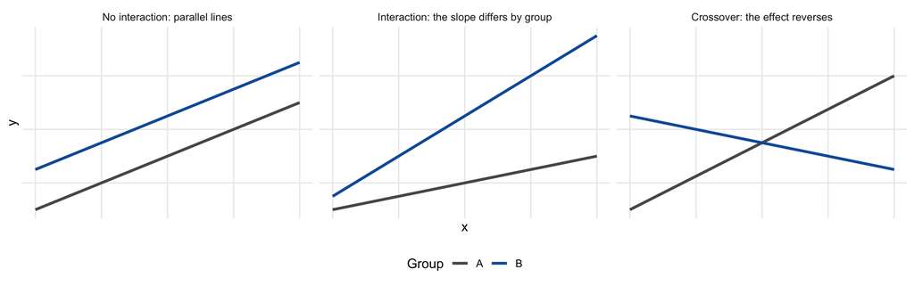

With a group indicator as $z$: **no interaction** = parallel lines (same slope, different level) · **interaction** = different slopes · **crossover** = the effect of $x$ reverses. $\beta_3$ is simply the **difference between the slopes**.

# 6.3 Continuous × categorical

## Face 1: a treatment effect that differs between groups

*Why a manager cares: if Smart Mix mainly helps free users, it belongs in the free tier’s roadmap and in the upgrade pitch — not in the Premium feature list.*

```r
model_plan <- lm(hours ~ smart_mix * premium + prior_hours + tenure, data = wave2)
round(coef(summary(model_plan)), 3)
```

```
                  Estimate Std. Error t value Pr(>|t|)
(Intercept)          1.560      0.469   3.327    0.001
smart_mix            4.999      0.378  13.212    0.000
premium              2.685      0.431   6.224    0.000
prior_hours          0.752      0.017  43.974    0.000
tenure               0.028      0.009   3.256    0.001
smart_mix:premium   -3.111      0.590  -5.273    0.000
```

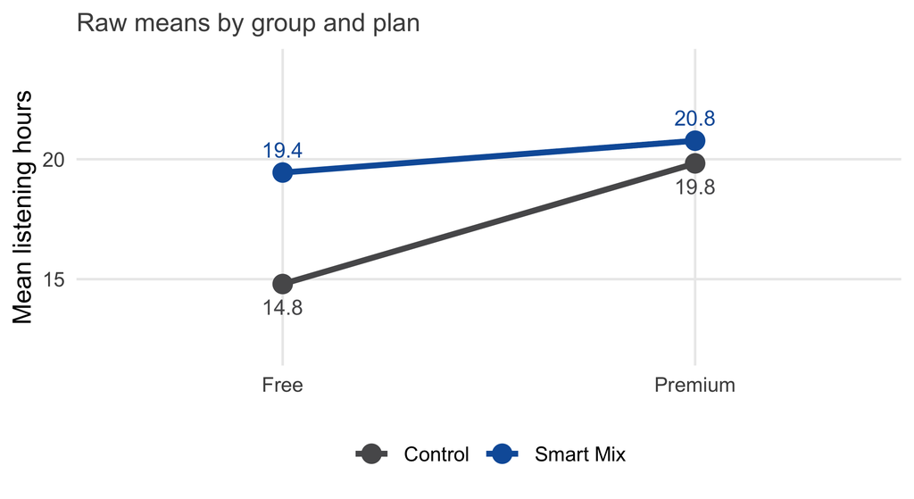

`smart_mix` = effect **for free users** (premium = 0): **5.0 h** · `smart_mix:premium` = how much the effect **differs** for Premium: **−3.1 h** (the heterogeneity test) · effect for Premium = 5.0 − 3.1 = **1.9 h** · `premium` = plan difference **in the control group**.

The chart shows **raw means**; the coefficients hold prior listening and tenure constant — which is why 5.0 and 1.9 are not exactly the gaps in the chart (4.6 and 1.0). Randomization makes both unbiased; the adjusted estimates are more precise.

## Face 1: the marginal effect of Smart Mix

$$\text{Effect of Smart Mix} \;=\; \beta_{\text{smart\_mix}} + \beta_{\text{smart\_mix:premium}} \times \text{premium}
\;=\; 5.00 - 3.11 \times \text{premium}$$

**From the coefficients:**

```r
b <- coef(model_plan)
b["smart_mix"] + b["smart_mix:premium"] * c(free = 0, premium = 1)
```

```
   free premium
  4.999   1.887
```

**With standard errors and confidence intervals** (`emmeans` package):

```r
library(emmeans)
emtrends(model_plan, ~ premium, var = "smart_mix")
```

```
 premium smart_mix.trend    SE   df lower.CL upper.CL
       0            5.00 0.378 1194    4.256     5.74
       1            1.89 0.453 1194    0.998     2.78

Results are averaged over the levels of: smart_mix
Confidence level used: 0.95
```

The interaction coefficient (−3.11, *p* < .001) tests whether the two effects **differ**; the marginal effects tell you **what they are**: 5.0 h (CI 4.3–5.7) for free users, 1.9 h (CI 1.0–2.8) for Premium users. Report both.

## Both effects with their uncertainty

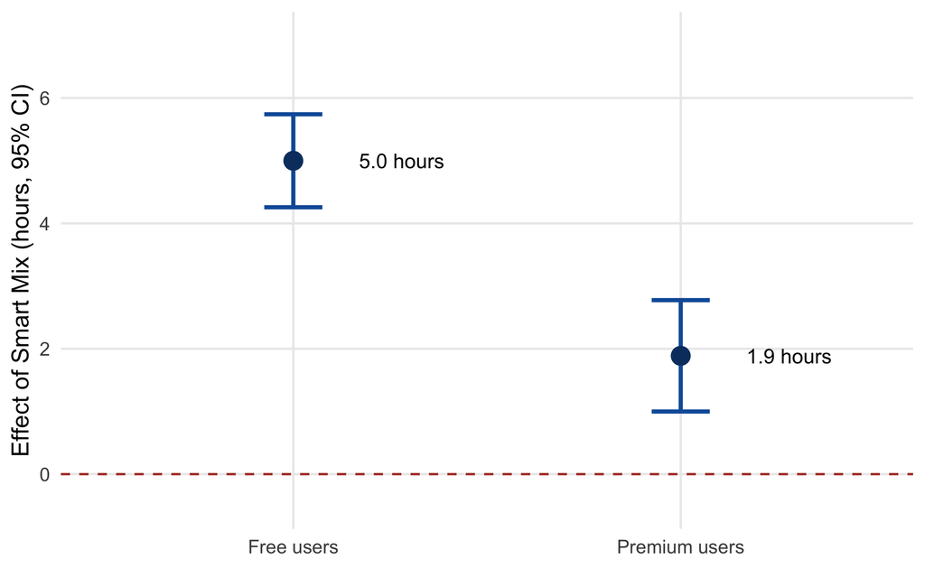

- The CI of the Premium effect is **not** in the regression output — it combines two coefficients and their covariance (`emtrends()` does it for you)
- Actionable: promote Smart Mix to **free users first**

The `emtrends()` table as a picture: what the product team should see.

## Face 2: a slope that differs between groups

*Why a manager cares: if the spend elasticity differs by genre, the next promotion euro should go where a percent of budget buys the most streams.*

```r
model_genre <- lm(log(streams) ~ log(spend) * genre +
                    log(followers) + placements, data = promo)
round(coef(summary(model_genre)), 3)
```

```
                              Estimate Std. Error t value Pr(>|t|)
(Intercept)                     -3.648      0.321 -11.357    0.000
log(spend)                       0.206      0.033   6.171    0.000
genreHipHop/Rap                 -2.058      0.430  -4.786    0.000
genreRock                        0.356      0.654   0.544    0.587
genreElectro/Dance               0.021      0.616   0.034    0.973
log(followers)                   0.507      0.015  33.456    0.000
placements                       0.122      0.011  11.417    0.000
log(spend):genreHipHop/Rap       0.268      0.052   5.178    0.000
log(spend):genreRock            -0.053      0.079  -0.669    0.504
log(spend):genreElectro/Dance    0.005      0.076   0.068    0.946
```

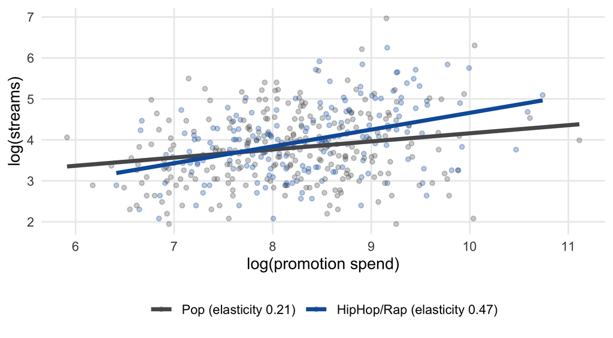

Same model, different question: `log(spend)` = elasticity for **Pop** (reference); `log(spend):genreHipHop/Rap` = **+0.27** → HipHop/Rap elasticity = 0.21 + 0.27 ≈ **0.47**. Rock and Electro: no evidence of a different slope. The genre “main effects” are level differences at `log(spend)` = 0, i.e., at a spend of **1 euro** (log(1) = 0) — not at a typical spend.

## Face 2: the elasticity of each genre

$$\text{Elasticity}_{\text{genre}} \;=\; \beta_{\log(\text{spend})} + \beta_{\log(\text{spend}):\text{genre}}
\qquad (\text{0 for the reference genre Pop})$$

**From the coefficients:**

```r
b <- coef(model_genre)
elasticity <- b["log(spend)"] +
  c(0, b["log(spend):genreHipHop/Rap"], b["log(spend):genreRock"],
    b["log(spend):genreElectro/Dance"])
names(elasticity) <- levels(promo$genre)
elasticity
```

```
          Pop    HipHop/Rap          Rock Electro/Dance
       0.2058        0.4737        0.1532        0.2109
```

**With confidence intervals:**

```r
emtrends(model_genre, ~ genre, var = "log(spend)")
```

```
 genre         log(spend).trend     SE  df lower.CL upper.CL
 Pop                      0.206 0.0334 590   0.1403    0.271
 HipHop/Rap               0.474 0.0396 590   0.3959    0.551
 Rock                     0.153 0.0712 590   0.0133    0.293
 Electro/Dance            0.211 0.0679 590   0.0776    0.344

Confidence level used: 0.95
```

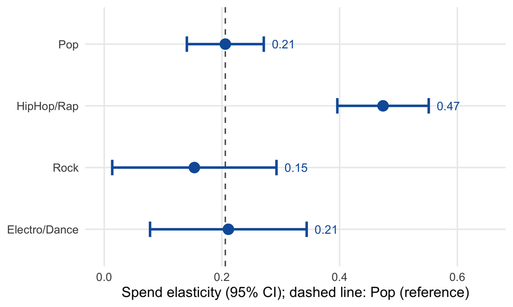

+1% spend → **+0.21%** streams for Pop, **+0.47%** for HipHop/Rap. The intervals of Rock and Electro/Dance overlap Pop’s: no evidence that their elasticities differ.

## Moderation by a continuous variable

*Why a manager cares: if light listeners gain the most, the feature’s onboarding should target them — heavy listeners need a different lever.*

```r
model_prior <- lm(hours ~ smart_mix * prior_hours +
                    premium + tenure, data = wave2)
round(coef(summary(model_prior)), 3)
```

```
                      Estimate Std. Error t value Pr(>|t|)
(Intercept)              1.446      0.532   2.720    0.007
smart_mix                5.391      0.660   8.164    0.000
prior_hours              0.797      0.023  34.426    0.000
premium                  1.041      0.301   3.462    0.001
tenure                   0.027      0.009   3.152    0.002
smart_mix:prior_hours   -0.096      0.034  -2.822    0.005
```

- `smart_mix:prior_hours` = −0.096: each hour of prior listening **reduces** the Smart Mix effect by 0.1 h — the interaction is significant (*p* = .005)
- `smart_mix` alone = effect at **zero** prior hours — a user who hardly exists

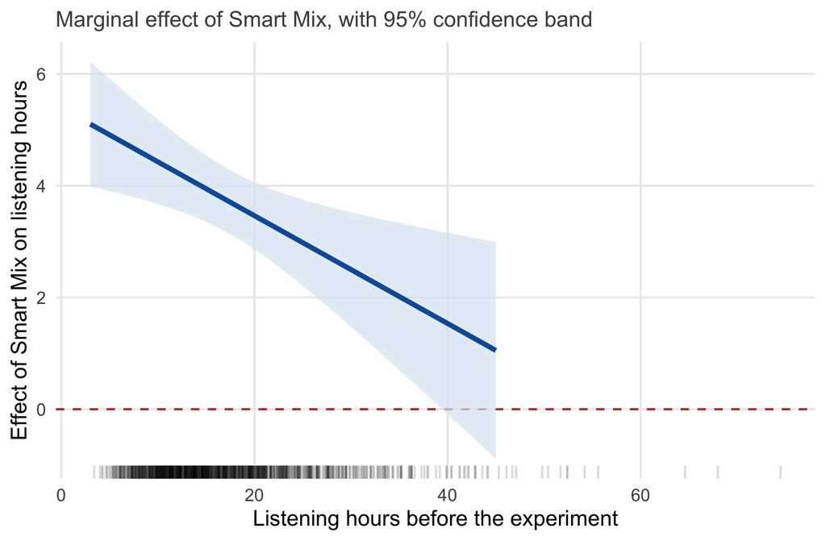

## The marginal effect at meaningful values

$$\text{Effect of Smart Mix} \;=\; \beta_{\text{smart\_mix}} + \beta_{\text{smart\_mix:prior\_hours}} \times \text{prior\_hours}
\;=\; 5.39 - 0.096 \times \text{prior\_hours}$$

**From the coefficients, at 10 / 20 / 30 hours:**

```r
b <- coef(model_prior)
b["smart_mix"] + b["smart_mix:prior_hours"] * c(10, 20, 30)
```

```
[1] 4.427 3.463 2.499
```

**With confidence intervals:**

```r
emtrends(model_prior, ~ prior_hours, var = "smart_mix",
         at = list(prior_hours = c(10, 20, 30)))
```

```
 prior_hours smart_mix.trend    SE   df lower.CL upper.CL
          10            4.43 0.385 1194     3.67     5.18
          20            3.46 0.307 1194     2.86     4.07
          30            2.50 0.523 1194     1.47     3.52

Results are averaged over the levels of: smart_mix, premium
Confidence level used: 0.95
```

With a continuous moderator, report the effect at **meaningful values** (e.g., the 10th / 50th / 90th percentile: 9, 15, 28 prior hours) or as a **curve with its confidence band** — never the coefficient at zero.

## Your turn (5 min)

Fit the interaction of Smart Mix with **device**:

```r
model_device <- lm(hours ~ smart_mix * device + prior_hours + premium + tenure, data = wave2)
round(coef(summary(model_device)), 3)
```

For which device is the effect of Smart Mix largest? Compute the effect for each device from the coefficients (or with `emtrends()`). Are the differences significant? (Why a manager cares: a device-specific effect would change the rollout order across the apps.)

# 6.4 Continuous × continuous

## Spend × followers: the uncentered model

*Why a manager cares: if promotion pays off more for artists with a large audience, the label can concentrate its budget on them — or deliberately counter “rich get richer”.*

$$\begin{aligned}
\log(\text{streams}) &= \beta_0 + \beta_1 \log(\text{spend}) + \beta_2 \log(\text{followers}) + \beta_3 \log(\text{spend}) \times \log(\text{followers}) + \dots \\
\text{Spend elasticity} &= \beta_1 + \beta_3 \log(\text{followers})
\end{aligned}$$

```r
model_cc <- lm(log(streams) ~ log(spend) * log(followers) + placements + genre, data = promo)
round(coef(summary(model_cc)), 3)
```

```
                          Estimate Std. Error t value Pr(>|t|)
(Intercept)                  5.410      1.506   3.593    0.000
log(spend)                  -0.896      0.183  -4.901    0.000
log(followers)              -0.422      0.143  -2.960    0.003
placements                   0.121      0.011  11.435    0.000
genreHipHop/Rap              0.165      0.044   3.767    0.000
genreRock                   -0.096      0.059  -1.624    0.105
genreElectro/Dance           0.065      0.058   1.129    0.260
log(spend):log(followers)    0.113      0.017   6.528    0.000
```

A **negative** spend elasticity (β₁ = −0.90)? It is the elasticity for an artist with `log(followers)` = 0 — **one follower** (log(1) = 0). Nobody in the data is anywhere near that (median: 36,000 followers). The **interaction** β₃ = **+0.113** (*p* < .001) is the real finding: each additional unit of `log(followers)` adds 0.11 to the spend elasticity — and one unit of `log(followers)` means a follower base **multiplied by e ≈ 2.7** (log(2.7 × followers) = log(followers) + 1). Promotion and reach **reinforce each other**: the same percentage budget increase buys a larger percentage gain for a bigger artist.

## Centered at the means

**The approach:** subtract each variable’s mean from every observation — nothing else changes. But the **zero point** of each variable is now the **mean of the data**, so the main effects become marginal effects *at the average artist* instead of at one follower and one euro.

```r
promo_c <- promo |>
  mutate(log_spend_c = log(spend) - mean(log(spend)),
         log_fol_c   = log(followers) - mean(log(followers)))
model_cc_centered <- lm(log(streams) ~ log_spend_c * log_fol_c + placements + genre, data = promo_c)
round(coef(summary(model_cc_centered)), 3)
```

```
                      Estimate Std. Error t value Pr(>|t|)
(Intercept)              3.411      0.044  77.500    0.000
log_spend_c              0.299      0.022  13.314    0.000
log_fol_c                0.508      0.015  33.870    0.000
placements               0.121      0.011  11.435    0.000
genreHipHop/Rap          0.165      0.044   3.767    0.000
genreRock               -0.096      0.059  -1.624    0.105
genreElectro/Dance       0.065      0.058   1.129    0.260
log_spend_c:log_fol_c    0.113      0.017   6.528    0.000
```

Now `log_spend_c` = **0.30** is the elasticity for an artist with an **average** (log) follower count (≈ 39,000 followers). The interaction, the other coefficients, R² and all predictions are **unchanged** — centering changes what the main effects *mean*, not the model.

## The marginal effect across the follower distribution

$$\text{Elasticity} \;=\; \beta_{\text{log\_spend\_c}} + \beta_{\text{log\_spend\_c:log\_fol\_c}} \times \big(\log(\text{followers}) - \overline{\log(\text{followers})}\big)$$

**At the 10th / 50th / 90th percentile of followers** (7,800 / 36,000 / 205,000):

```r
b <- coef(model_cc_centered)
fol_q <- quantile(promo$followers, c(0.1, 0.5, 0.9))
b["log_spend_c"] + b["log_spend_c:log_fol_c"] *
  (log(fol_q) - mean(log(promo$followers)))
```

```
   10%    50%    90%
0.1175 0.2917 0.4869
```

Small artist: +10% spend → **+1.2%** streams. Big artist: **+4.9%**. Communicate with the **plot**, not with the table.

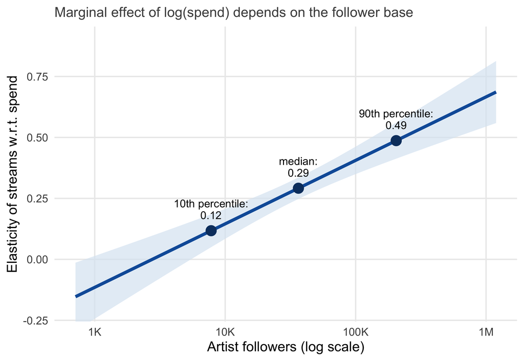

# 6.5 Categorical × categorical: a 2 × 3 experiment

## Are AI-made ads judged as creative as human-made ads?

*Why a manager cares: whether to disclose AI involvement is a policy decision — the interaction says when disclosure costs creativity points, and when it does not.*

- **360 respondents** rate the creativity of an ad (0–100)
- Factor 1 — **source** of the design: Human · AI · Human + AI
- Factor 2 — **disclosure**: source revealed · not revealed
- 2 × 3 = **6 cells**, 60 respondents each, randomized

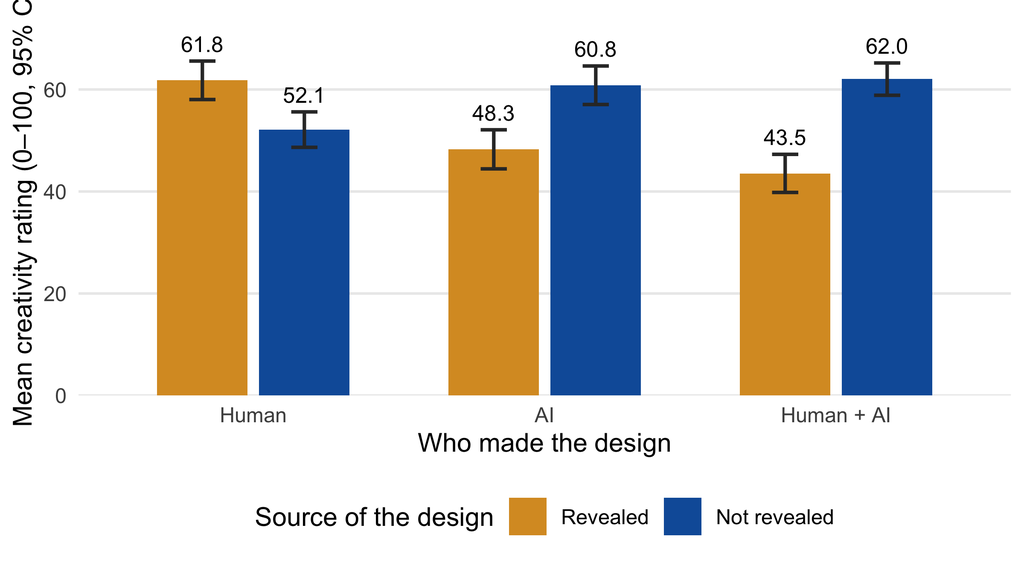

Revealed: human designs win. Not revealed: AI and hybrid designs are rated **as creative** — slightly higher. **Crossing lines = the effect of the source depends on disclosure.**

## The regression: six coefficients, six cell means

```r
model_ads <- lm(creativity ~ source * disclosure, data = ads)
round(coef(summary(model_ads)), 3)
```

```
                                        Estimate Std. Error t value Pr(>|t|)
(Intercept)                               61.800      1.854  33.330        0
sourceAI                                 -13.533      2.622  -5.161        0
sourceHuman + AI                         -18.250      2.622  -6.960        0
disclosureNot revealed                    -9.667      2.622  -3.686        0
sourceAI:disclosureNot revealed           22.233      3.708   5.996        0
sourceHuman + AI:disclosureNot revealed   28.150      3.708   7.591        0
```

| Coefficient | Value | Meaning (reference cell: Human, Revealed) |
| --- | --- | --- |
| `(Intercept)` | 61.8 | Mean rating of **human** designs when the source is **revealed** |
| `sourceAI` | −13.5 | AI designs, *when revealed*, vs. human designs |
| `sourceHuman + AI` | −18.3 | Hybrid designs, *when revealed*, vs. human designs |
| `disclosureNot revealed` | −9.7 | *Human* designs: not revealed vs. revealed |
| `sourceAI:disclosureNot revealed` | +22.2 | The **extra** gain of AI designs when not revealed, beyond the two main effects |
| `sourceHuman + AI:disclosureNot revealed` | +28.2 | The same for hybrid designs |

**Rebuilding a cell:** AI, not revealed = 61.8 − 13.5 − 9.7 + 22.2 = **60.8** — the observed cell mean. Any cell mean is the sum of the coefficients that apply to it.

## Step 1: is there an interaction at all?

```r
anova(model_ads)
```

```
Analysis of Variance Table

Response: creativity
                   Df Sum Sq Mean Sq F value  Pr(>F)
source              2   1055     527    2.56   0.079 .
disclosure          1   4572    4572   22.17 3.6e-06 ***
source:disclosure   2  13218    6609   32.04 1.6e-13 ***
Residuals         354  73021     206
---
Signif. codes:  0 '***' 0.001 '**' 0.01 '*' 0.05 '.' 0.1 ' ' 1
```

The ANOVA table tests each factor and the **interaction as a whole** (two coefficients at once). Interaction highly significant → the effect of the source depends on disclosure → **do not interpret the main effects on their own**. (Unbalanced cells: `car::Anova(model_ads, type = 2)`.)

## Step 2: which cells differ? Estimated marginal means

```r
emm <- emmeans(model_ads, ~ source | disclosure)
pairs(emm, adjust = "bonferroni")       # Tukey instead: pairs(emm), the default
```

```
disclosure = Revealed:
 contrast             estimate   SE  df t.ratio p.value
 Human - AI              13.53 2.62 354   5.161  <.0001
 Human - (Human + AI)    18.25 2.62 354   6.960  <.0001
 AI - (Human + AI)        4.72 2.62 354   1.799  0.2187

disclosure = Not revealed:
 contrast             estimate   SE  df t.ratio p.value
 Human - AI              -8.70 2.62 354  -3.318  0.0030
 Human - (Human + AI)    -9.90 2.62 354  -3.775  0.0006
 AI - (Human + AI)       -1.20 2.62 354  -0.458  1.0000

P value adjustment: bonferroni method for 3 tests
```

From “there is an interaction” to “**where exactly** are the differences”: revealed → human beats AI (14 points) and hybrid; not revealed → AI and hybrid beat human by 9–10 points. *p*-values **Bonferroni-adjusted** for the three comparisons within each disclosure condition, as in Chapter 4 (Tukey’s HSD gives the same picture with slightly smaller *p*-values) — the two-step logic of the one-way ANOVA, with one extra dimension.

## Your turn (5 min)

1. Rebuild the cell mean for **hybrid** designs with the source **not revealed** from the coefficients of `model_ads`. Check it against the table of cell means.
2. Which **single number** in the regression output answers: “does disclosure change the rating of hybrid designs *more* than it changes the rating of human designs?”

# 6.7 Mediation: why does it work?

## Total = direct + indirect

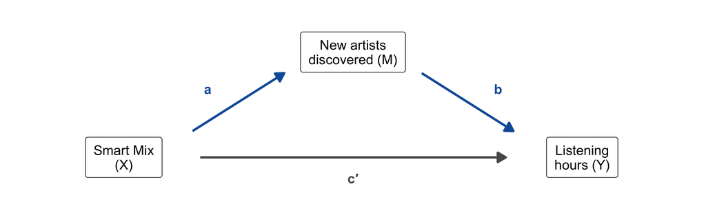

- **Indirect effect** = **a × b**: Smart Mix → new artists → hours — the *average causal mediation effect* (**ACME**)
- **Direct effect** c′: everything else (convenience, habit, curiosity) — the *average direct effect* (**ADE**)
- **Total** = direct + indirect

Hypothesis of the product team: Smart Mix works **because** it makes users discover new music. If true, improving discovery improves the effect.

## Three regressions

```r
model_m <- lm(new_artists ~ smart_mix + prior_hours + premium, data = wave2)                    # path a
model_y <- lm(hours ~ smart_mix + new_artists + prior_hours + premium + tenure, data = wave2)   # paths b and c'
a <- coef(model_m)["smart_mix"]; b <- coef(model_y)["new_artists"]; c_direct <- coef(model_y)["smart_mix"]
c(a = unname(a), b = unname(b), direct = unname(c_direct), indirect = unname(a * b), total = unname(c_direct + a * b))
```

```
       a        b   direct indirect    total
  3.6185   0.3909   2.3063   1.4146   3.7209
```

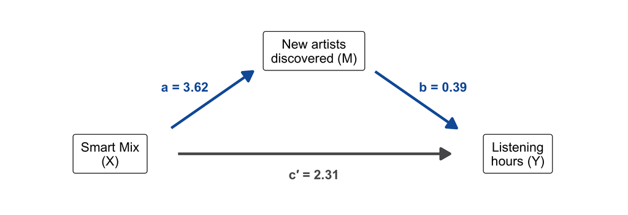

- **a** = 3.6 more new artists with Smart Mix
- **b** = 0.39 hours per new artist, holding Smart Mix constant
- **c′** = 2.31 hours direct — down from the total 3.72

Indirect effect a × b = **1.41 hours = 38%** of the effect runs through discovery. Discovery is **an** important mechanism — not the only one.

## Uncertainty of the indirect effect: bootstrap

```r
set.seed(1)
boot_indirect <- replicate(2000, {
  d_boot <- wave2[sample(nrow(wave2), replace = TRUE), ]
  coef(lm(new_artists ~ smart_mix + prior_hours + premium, data = d_boot))["smart_mix"] *
    coef(lm(hours ~ smart_mix + new_artists + prior_hours + premium + tenure, data = d_boot))["new_artists"]
})
quantile(boot_indirect, c(0.025, 0.975))
```

```
  2.5%  97.5%
0.9861 1.8632
```

A product of two estimates is **not normally distributed** → no textbook standard error → **bootstrap** (Chapter 3): resample users, re-estimate both regressions, look at the distribution of a × b. Report **total, direct, indirect** with uncertainty, plus the **share mediated**.

## The same in one call: the `mediation` package

```r
library(mediation)                       # install.packages("mediation")
med <- mediate(model_m, model_y, treat = "smart_mix", mediator = "new_artists", boot = TRUE, sims = 1000)
summary(med)
```

```
Causal Mediation Analysis
Nonparametric Bootstrap Confidence Intervals with the Percentile Method

               Estimate 95% CI Lower 95% CI Upper p-value
ACME              1.415        0.981        1.848  <2e-16 ***
ADE               2.306        1.628        3.001  <2e-16 ***
Total Effect      3.721        3.151        4.298  <2e-16 ***
Prop. Mediated    0.380        0.261        0.516  <2e-16 ***

Sample Size Used: 1200       Simulations: 1000
```

**ACME** = indirect effect (a × b), **ADE** = direct effect c′, **Prop. Mediated** = share. Same numbers as our three regressions + bootstrap — the package automates exactly that (and also handles logistic outcomes). Either is fine for your project; the manual version shows *what* is being computed.

## The catch: nobody randomized the mediator

Live demo: book §6.7 — mediation widget, switch on the **unobserved confounder of M and Y**

https://wu-rds.github.io/MA2026/06-mechanisms.html#sec-mech-mediation

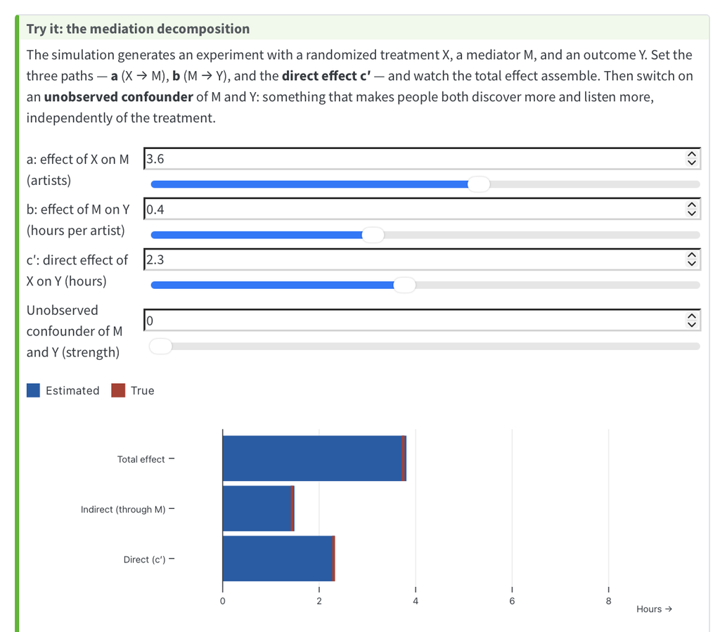

Randomization identifies the **total** effect. The **split** needs one more assumption: **no unobserved confounder of mediator and outcome** (curious users discover more *and* listen more). Untestable — and the same problem as Chapter 5, one step down the chain.

What helps: measure likely confounders of M **before** the manipulation; **manipulate the mediator** (Smart Mix with vs. without discovery).

# 6.8 Your group project

## One moderator and one mediator — with 120 respondents

**Your moderator** *(at least one)*

- With an **expected direction** stated in advance: “the label works better for environmentally concerned respondents”
- Measured **before** the manipulation (so it cannot be affected by it)
- `outcome ~ condition * moderator`; report the effect at **meaningful values**
- 60 per condition → only **large** interactions detectable; “no evidence that the effect differs” is a legitimate result

**Your mediator** *(at least one)*

- The **mechanism** you believe in: perceived quality, trust, authenticity, attention …
- Measured **after** the manipulation, before the outcome
- Three regressions + bootstrap (or `mediate()`); report **total, direct, indirect, share**
- State the assumption — and measure plausible confounders of mediator and outcome **before** the manipulation

Plan both in the questionnaire **now** (next session: survey design). In the report: what was **planned**, what was **exploratory**.

## Coding block: two cases (40 min)

**Case 1: the climate-neutral shipping label** — `green_label.csv`: 1,000 customers of an online shop, **randomized** label at checkout (`label` 1/0), order value in euros, segment (new/returning), sustainability score 1–7 (`eco_score`, from an earlier survey).

1. Mean order value by **label × segment**, plotted: parallel or not?
2. `order_value ~ label * segment`: the label effect for **each segment** from the coefficients and with `emtrends()`; do the effects differ?
3. `order_value ~ label * eco_score`: the effect at a score of **2, 4, 6**; what does the coefficient of `label` alone mean?

**Laptops open — alone or with your neighbor.** Section “Coding block” in `06-mechanisms.R`.

**Case 2: the story behind the coffee** — `coffee_story.csv`: a survey experiment, 320 respondents, **randomized** product description (`version`: Facts / Story), perceived `authenticity` (1–7, **after**), `wtp` for a 250 g pack (euros), `involvement` (1–7, **before**).

1. **Total effect** of the story on willingness to pay, with CI
2. The three paths **a, b, c′** (with `involvement` as control); indirect effect and **share mediated**
3. **Bootstrap CI** of the indirect effect (or `mediate()`)
4. Which assumption does the split rely on — and what would you add to the questionnaire?

At the end: one table presents case 1, another case 2 — Menti first: your label effect for new customers (case 1) and your share mediated (case 2).

## Learning check

1. `smart_mix` = 5.0, `smart_mix:premium` = −3.1. Effect for free users? For Premium? What does the interaction’s *p*-value test?
2. 2 × 2: intercept 40, `framingYearly` −5, `trialYes` +8, `framingYearly:trialYes` +6. The four cell means? Where does the trial help more?
3. A loyalty program’s effect on annual spending is estimated with “store visits” as a control — visits are a *consequence* of the program. What does the program’s coefficient estimate now, and what if you want the total effect?
4. 25 segments tested, “works particularly well for returning customers on tablets” (*p* = .02). Problem — and what next?

## Next session

**Module 8 · Survey design** — *from research question to questionnaire*

- Measuring constructs: items, scales, reliability
- Embedding your experiment in a Qualtrics survey — including your **moderator** (before) and **mediator** (after)
- Questionnaire structure, pretesting, data collection

Bring your group’s **research question and planned manipulation** — we will work on your questionnaires in class.